# Série Chronologique - Projet

```r
library(TSA)
library(tseries)
library(forecast)
source(file = "checkup_res.R")
```

# Introduction

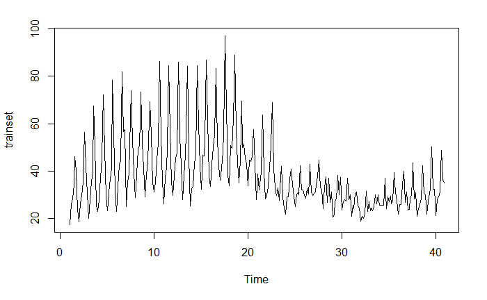

```r
data = read.csv('orders.csv')
trainset = ts(data$n_orders[1:280], frequency=7)
testset = ts(data$n_orders[281:328], frequency=7)
plot(trainset, type='l')
```

Cette série présente plusieurs caractéristiques remarquables.

Il y a une forte saisonalité sur les jours de la semaine. En effet, le nombre de commandes croit du dimanche au vendredi puis décroît le samedi en moyenne.

La série semble composée de deux voir trois régime. Un premier lors des 18 premières semaines avant une tendance haussière, une saisonnalité très marquée et une variance relativement grande. Puis, vient 16 semaines de tendance baissière, avec une saisonnalité moins marquée et une plus faible variance. Enfin, les 5 dernières semaines semble reprendre quelque peu le schéma de premières semaine avec un tendance à la hausse, une saisonnalité marquée et une variance qui augmente.

```r
t1 = 1:126; X1 = trainset[t1]
t2 = 127:246; X2 = trainset[t2]
t3 = 247:280; X3 = trainset[t3]
lm1 = lm(X1~t1)
lm2 = lm(X2~t2)
lm3 = lm(X3~t3)
plot(1:length(trainset), trainset, type='l', xlab="Période", ylab="Commandes")
lines(t2, X2, type="l", col="blue")
```

```r
lines(t3, X3, type="l", col="red")
lines(t1, lm1$coefficients[1]+ t1 * lm1$coefficients[2])
```

[figure not shown]

```r
lines(t2, lm2$coefficients[1]+ t2 * lm2$coefficients[2], col="blue")
lines(t3, lm3$coefficients[1]+ t3 * lm3$coefficients[2], col="red")
```

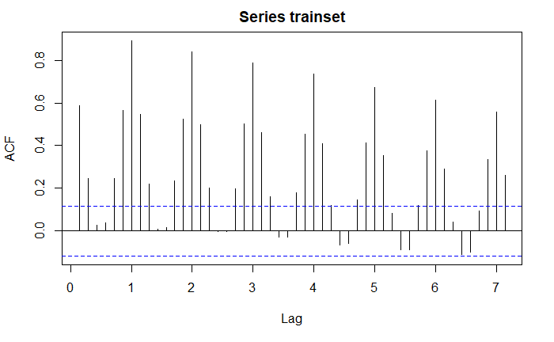

```r
acf(trainset, lag.max = 50)
```

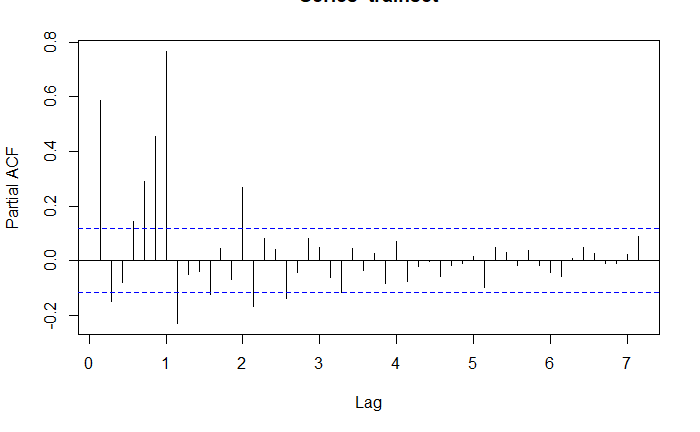

```r
pacf(trainset, lag.max = 50)
```

```r
Box.test(trainset, type="Ljung-Box", lag=7)
```

```
    Box-Ljung test

data:  trainset
X-squared = 456.32, df = 7, p-value < 2.2e-16
```

```r
adf.test(trainset)
```

```
    Augmented Dickey-Fuller Test

data:  trainset
Dickey-Fuller = -2.5577, Lag order = 6, p-value = 0.3411
alternative hypothesis: stationary
```

```r
kpss.test(trainset)
```

```
p-value smaller than printed p-value
```

```
    KPSS Test for Level Stationarity

data:  trainset
KPSS Level = 2.4803, Truncation lag parameter = 5, p-value = 0.01
```

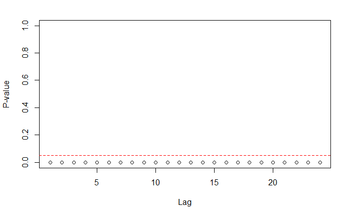

```r
McLeod.Li.test(y=trainset)
```

Analysons le résultats des tests.

L’ACF présente des pics périodiques significatifs majoritairement. On ne peut donc pas conclure que la série est stationnaire car elle possède une composante saisonnière.

En conclusion, la série n’est pas stationnaire car elle présente une saisonalité d’ordre 7 et une variance qui évolue au fil du temps. Il peut être intéressant d’appliquer des transformations pour atténuer les variations de cette dernière.

Dans la partie suivante, nous allons implémenter plusieurs approches afin de rendre la série stationnaire. Premièrement, nous appliquerons un modèle simple, la décomposition. Puis dans un second et troisième temps, nous testerons des méthodes de différenciation et de régression.

# Stationarité

## Decompose

La fonction `decompose` renvoie une tendance, une composante saisonnière ainsi que des résidus.

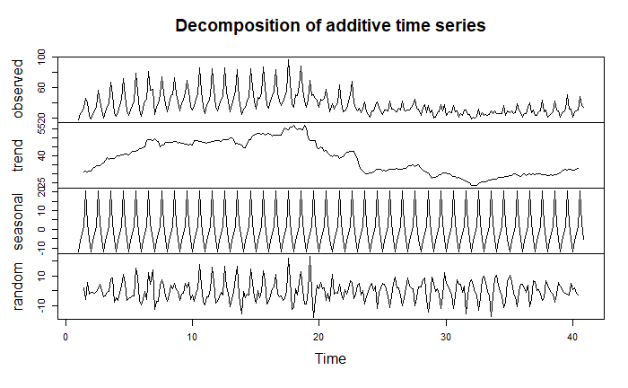

```r
decomp = decompose(trainset)
plot(decomp)
```

La fonction `decompose` détermine d’abord la composante de tendance en utilisant une moyenne mobile, et la supprime de la série chronologique. Ici, on voit que l’on pourrait l’approximer par une tendance d’ordre 3. Ensuite, la figure saisonnière est calculée en faisant la moyenne, pour chaque unité de temps, de toutes les périodes. La figure saisonnière est ensuite centrée. Enfin, la composante d’erreur est déterminée en retirant la tendance et la figure saisonnière (dupliquée si nécessaire) de la série temporelle originale.

Analysons à présent les résidus.

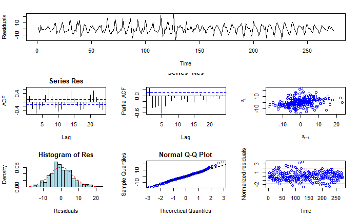

```r
checkupRes(decomp$random[which(!is.na(decomp$random))])
```

```r
Box.test(decomp$random, type="Ljung-Box", lag=7)
```

```
    Box-Ljung test

data:  decomp$random
X-squared = 314.68, df = 7, p-value < 2.2e-16
```

```r
Box.test(decomp$random)
```

```
    Box-Pierce test

data:  decomp$random
X-squared = 18.541, df = 1, p-value = 1.663e-05
```

```r
kpss.test(decomp$random)
```

```
p-value greater than printed p-value
```

```
    KPSS Test for Level Stationarity

data:  decomp$random
KPSS Level = 0.019331, Truncation lag parameter = 5, p-value = 0.1
```

```r
adf.test(decomp$random[which(!is.na(decomp$random))])
```

```
p-value smaller than printed p-value
```

```
    Augmented Dickey-Fuller Test

data:  decomp$random[which(!is.na(decomp$random))]
Dickey-Fuller = -12.277, Lag order = 6, p-value = 0.01
alternative hypothesis: stationary
```

```r
shapiro.test(decomp$random)
```

```
    Shapiro-Wilk normality test

data:  decomp$random
W = 0.98973, p-value = 0.05014
```

## Différenciation sur la série sans transformation

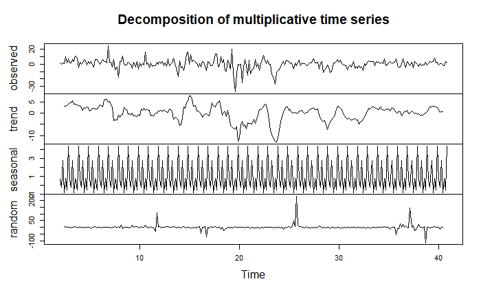

```r
diff7 = diff(trainset, 7)
decomp7 = decompose(diff7, type="multiplicative")
plot(decomp7)
```

```
    Box-Ljung test

data:  res
X-squared = 5.3727, df = 7, p-value = 0.6146


    KPSS Test for Level Stationarity

data:  res
KPSS Level = 0.053636, Truncation lag parameter = 5, p-value = 0.1


    Augmented Dickey-Fuller Test

data:  res[which(!is.na(res))]
Dickey-Fuller = -5.4334, Lag order = 6, p-value = 0.01
alternative hypothesis: stationary


    Shapiro-Wilk normality test

data:  res
W = 0.36657, p-value < 2.2e-16
```

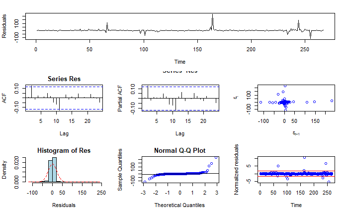

```r
check_stat(decomp7$random)
```

Avec un différentiation d’ordre 7 et une décomposition on obtient un bruit banc non-gausien.

Differenciation I-B⁷

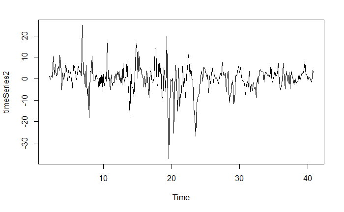

```r
timeSeries2 = diff(trainset,7)
plot(timeSeries2)
```

```r
kpss.test(timeSeries2)
```

```
p-value greater than printed p-value
```

```
    KPSS Test for Level Stationarity

data:  timeSeries2
KPSS Level = 0.32418, Truncation lag parameter = 5, p-value = 0.1
```

```r
adf.test(timeSeries2)
```

```
p-value smaller than printed p-value
```

```
    Augmented Dickey-Fuller Test

data:  timeSeries2
Dickey-Fuller = -7.2702, Lag order = 6, p-value = 0.01
alternative hypothesis: stationary
```

Les tests vont dans le sens de la stationnarité

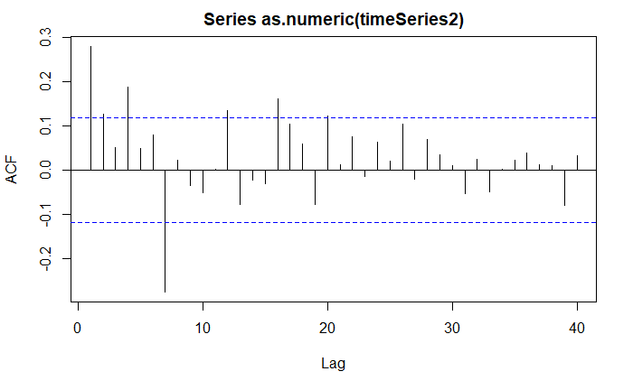

```r
acf(as.numeric(timeSeries2), lag.max=40)
```

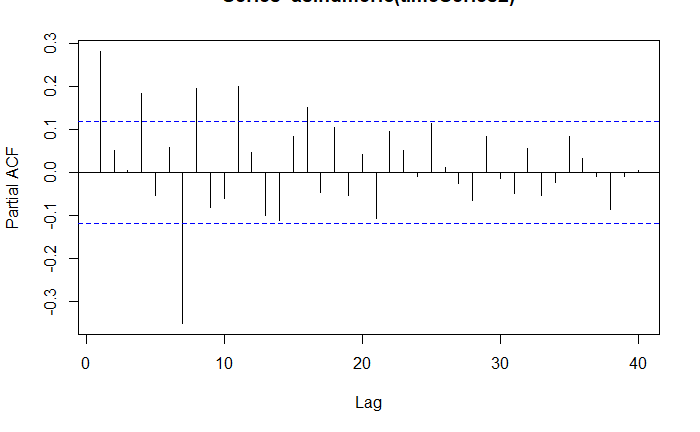

```r
pacf(as.numeric(timeSeries2), lag.max=40)
```

On retrouve une série dont l’allure est en accord avec la stationnarité On peut essaie de différencier à nouveau la série

Differenciation (I-B)(I-B⁷)

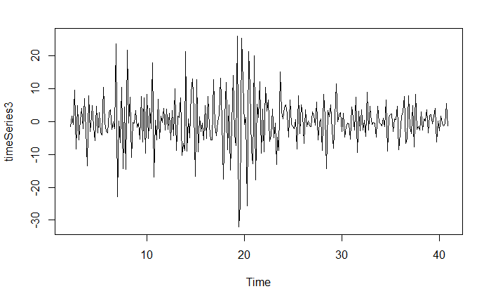

```r
timeSeries3 = diff(diff(trainset,7))
plot(timeSeries3)
```

```r
kpss.test(timeSeries3)
```

```
p-value greater than printed p-value
```

```
    KPSS Test for Level Stationarity

data:  timeSeries3
KPSS Level = 0.013192, Truncation lag parameter = 5, p-value = 0.1
```

```r
adf.test(timeSeries3)
```

```
p-value smaller than printed p-value
```

```
    Augmented Dickey-Fuller Test

data:  timeSeries3
Dickey-Fuller = -9.5796, Lag order = 6, p-value = 0.01
alternative hypothesis: stationary
```

Les tests vont dans le sens de la stationnarité

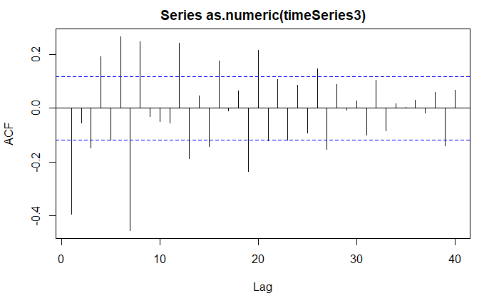

```r
acf(as.numeric(timeSeries3), lag.max=40)
```

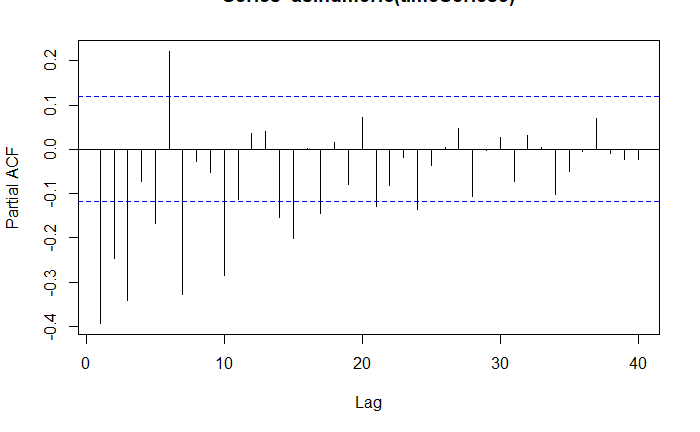

```r
pacf(as.numeric(timeSeries3), lag.max=40)
```

Conclusion : Les deux différenciations semblent utilisables pour établir des modèles

Premier modèle :

```r
mod1 = auto.arima(trainset,allowmean = TRUE, D = 0,d = 1, allowdrift = TRUE)
mod1
```

```
Series: trainset
ARIMA(1,1,1)(2,0,0)[7]

Coefficients:
         ar1      ma1    sar1    sar2
      0.3163  -0.9519  0.5517  0.3469
s.e.  0.0651   0.0236  0.0563  0.0566

sigma^2 estimated as 32.33:  log likelihood=-884.07
AIC=1778.15   AICc=1778.37   BIC=1796.31
```

Tous les termes sont significatifs

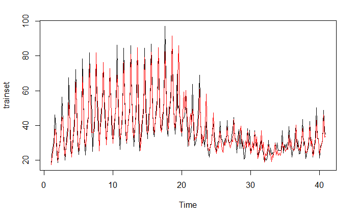

```r
plot(trainset)
lines(mod1$fitted,col='red')
```

Analyse des résidus du modèle

```
    Box-Ljung test

data:  res
X-squared = 12.131, df = 7, p-value = 0.09634


    KPSS Test for Level Stationarity

data:  res
KPSS Level = 0.14203, Truncation lag parameter = 5, p-value = 0.1


    Augmented Dickey-Fuller Test

data:  res[which(!is.na(res))]
Dickey-Fuller = -5.6378, Lag order = 6, p-value = 0.01
alternative hypothesis: stationary


    Shapiro-Wilk normality test

data:  res
W = 0.92849, p-value = 2.345e-10
```

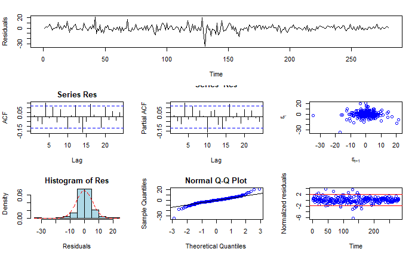

```r
check_stat(mod1$residuals)
```

Second modèle :

```r
mod2 = auto.arima(trainset,allowmean = TRUE, D = 1,d = 1, allowdrift = TRUE)
mod2
```

```
Series: trainset
ARIMA(2,1,3)(1,1,1)[7]

Coefficients:
          ar1      ar2     ma1      ma2      ma3    sar1     sma1
      -1.1943  -0.4392  0.6001  -0.5391  -0.6501  0.1048  -0.6507
s.e.   0.1502   0.1468  0.1259   0.0804   0.0971  0.1038   0.0743

sigma^2 estimated as 29.19:  log likelihood=-843.93
AIC=1703.86   AICc=1704.4   BIC=1732.7
```

Tous les termes sauf sar1 sont significatifs, il serait donc judicieux de “retrograder” notre modèle :

```r
mod2 = Arima(trainset,order = c(2,1,3), seasonal = list(order=c(0,1,1), period=7), include.mean = TRUE, include.drift = TRUE)
```

```
No drift term fitted as the order of difference is 2 or more.
```

```r
mod2
```

```
Series: trainset
ARIMA(2,1,3)(0,1,1)[7]

Coefficients:
          ar1     ar2     ma1      ma2      ma3     sma1
      -0.9595  0.0086  0.3687  -0.8016  -0.2745  -0.6000
s.e.   0.1684  0.1639  0.1582   0.0588   0.1212   0.0557

sigma^2 estimated as 29.65:  log likelihood=-846.54
AIC=1707.07   AICc=1707.5   BIC=1732.31
```

Encore une fois, on a un terme non significatif (ar2), on va encore rétrograder notre modèle

```r
mod2 = Arima(trainset,order = c(1,1,3), seasonal = list(order=c(0,1,1), period=7), include.mean = TRUE, include.drift = TRUE)
```

```
No drift term fitted as the order of difference is 2 or more.
```

```r
mod2
```

```
Series: trainset
ARIMA(1,1,3)(0,1,1)[7]

Coefficients:
          ar1     ma1      ma2      ma3     sma1
      -0.8130  0.2458  -0.6699  -0.3148  -0.6022
s.e.   0.1241  0.1184   0.0971   0.0670   0.0558

sigma^2 estimated as 29.56:  log likelihood=-846.64
AIC=1705.28   AICc=1705.6   BIC=1726.91
```

Cette troisième tentative semble meilleure du point de vue du BIC et équivalente du point de vue de l’AIC

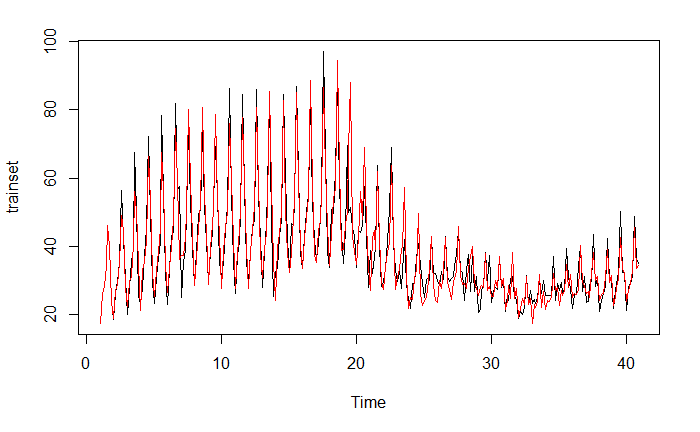

```r
plot(trainset)
lines(mod2$fitted,col='red')
```

Analyse des résidus du modèle

```
    Box-Ljung test

data:  res
X-squared = 2.8752, df = 7, p-value = 0.8963


    KPSS Test for Level Stationarity

data:  res
KPSS Level = 0.20298, Truncation lag parameter = 5, p-value = 0.1


    Augmented Dickey-Fuller Test

data:  res[which(!is.na(res))]
Dickey-Fuller = -5.6634, Lag order = 6, p-value = 0.01
alternative hypothesis: stationary


    Shapiro-Wilk normality test

data:  res
W = 0.90927, p-value = 5.766e-12
```

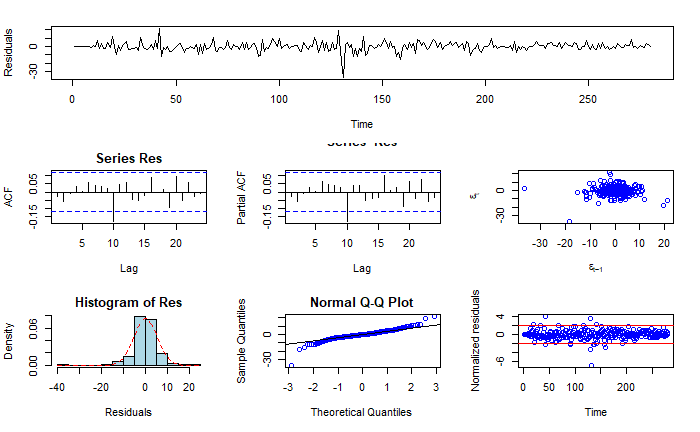

```r
check_stat(mod2$residuals)
```

On a constaté que notre série présente une variance très variable au cours du temps, on peut tenter de corriger ce problème par une transformation logarithmique

## Transformation logarithmique et différenciation

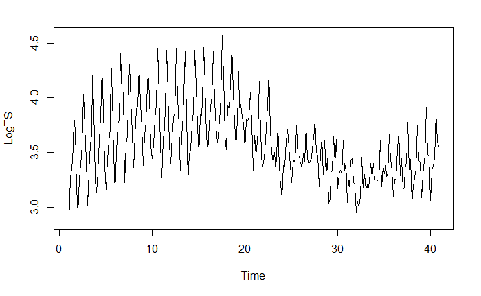

```r
LogTS = ts(log(trainset), start=1, frequency = 7)
plot(LogTS)
```

On a réussi à bien réduire la variance. Voyons ce que disent les tests ADF et KPSS.

```r
kpss.test(LogTS)
```

```
p-value smaller than printed p-value
```

```
    KPSS Test for Level Stationarity

data:  LogTS
KPSS Level = 2.4409, Truncation lag parameter = 5, p-value = 0.01
```

```r
adf.test(LogTS)
```

```
    Augmented Dickey-Fuller Test

data:  LogTS
Dickey-Fuller = -2.6007, Lag order = 6, p-value = 0.323
alternative hypothesis: stationary
```

Les tests vont dans le sens de la non-stationnarité, ce qui est confirmé par l’analyse visuelle.

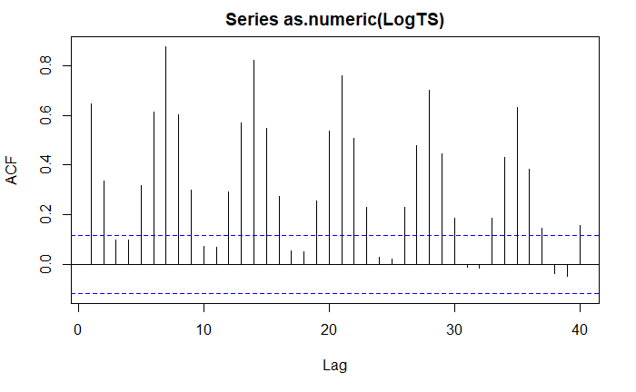

```r
acf(as.numeric(LogTS), lag.max=40)
```

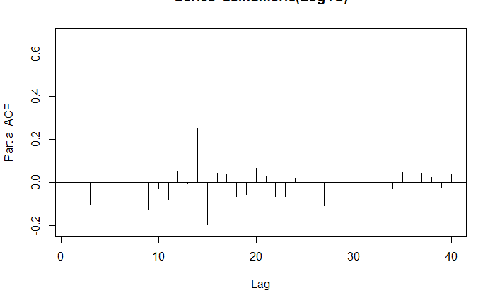

```r
pacf(as.numeric(LogTS), lag.max=40)
```

On retrouve dans l’ACF un fort motif périodique

Differenciation I-B

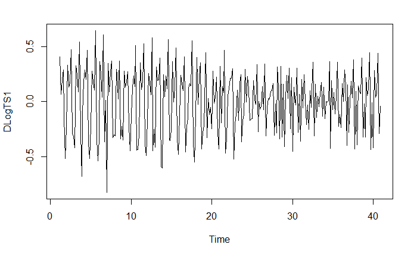

```r
DLogTS1 = diff(LogTS)
plot(DLogTS1)
```

```r
kpss.test(DLogTS1)
```

```
p-value greater than printed p-value
```

```
    KPSS Test for Level Stationarity

data:  DLogTS1
KPSS Level = 0.079108, Truncation lag parameter = 5, p-value = 0.1
```

```r
adf.test(DLogTS1)
```

```
p-value smaller than printed p-value
```

```
    Augmented Dickey-Fuller Test

data:  DLogTS1
Dickey-Fuller = -11.709, Lag order = 6, p-value = 0.01
alternative hypothesis: stationary
```

Les tests vont dans le sens de la stationnarité

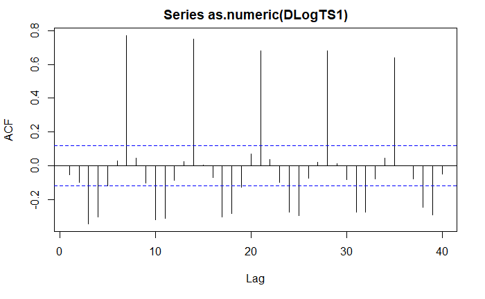

```r
acf(as.numeric(DLogTS1), lag.max=40)
```

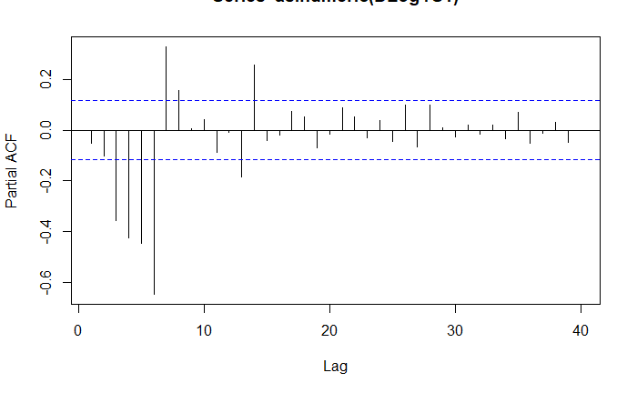

```r
pacf(as.numeric(DLogTS1), lag.max=40)
```

Mais pas l’ACF où un motif périodique se dessine clairement. On voit néanmois qu’on a réussi à éliminer la tendance. Pour éliminer le motif périodique, essayons une différenciation d’ordre 7

Differenciation I-B⁷

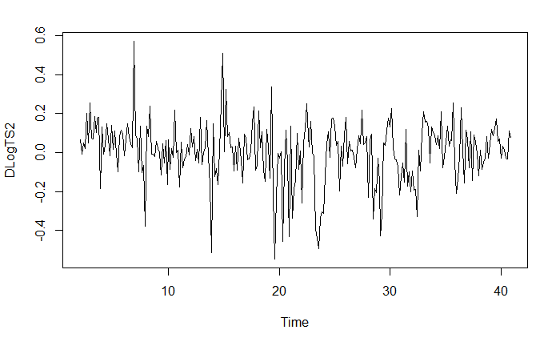

```r
DLogTS2 = diff(LogTS,7)
plot(DLogTS2)
```

```r
kpss.test(DLogTS2)
```

```
p-value greater than printed p-value
```

```
    KPSS Test for Level Stationarity

data:  DLogTS2
KPSS Level = 0.31195, Truncation lag parameter = 5, p-value = 0.1
```

```r
adf.test(DLogTS2)
```

```
p-value smaller than printed p-value
```

```
    Augmented Dickey-Fuller Test

data:  DLogTS2
Dickey-Fuller = -8.0099, Lag order = 6, p-value = 0.01
alternative hypothesis: stationary
```

Les tests vont dans le sens de la stationnarité

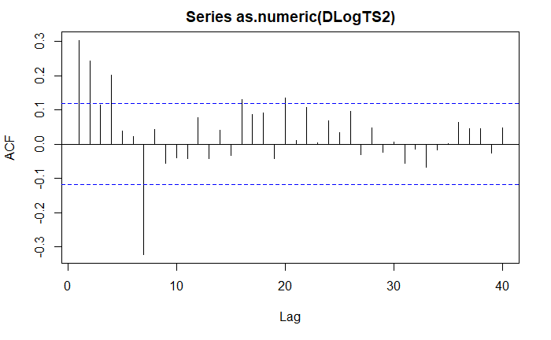

```r
acf(as.numeric(DLogTS2), lag.max=40)
```

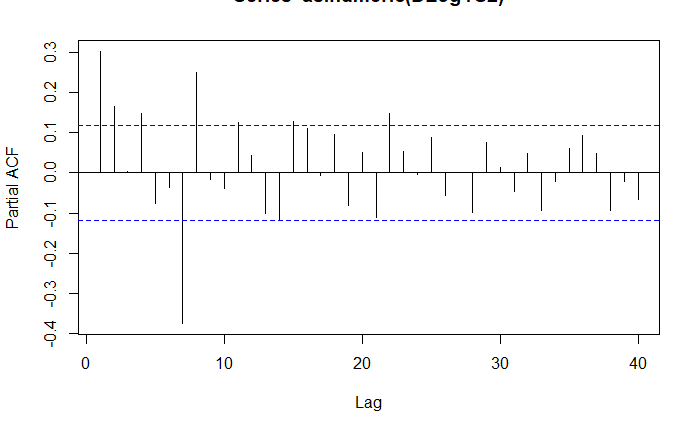

```r
pacf(as.numeric(DLogTS2), lag.max=40)
```

Differenciation (I-B)(I-B⁷)

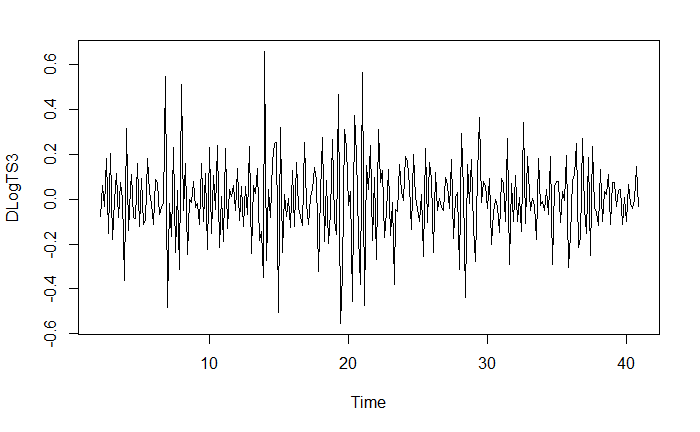

```r
DLogTS3 = diff(diff(LogTS,7))
plot(DLogTS3)
```

```r
kpss.test(DLogTS3)
```

```
p-value greater than printed p-value
```

```
    KPSS Test for Level Stationarity

data:  DLogTS3
KPSS Level = 0.013689, Truncation lag parameter = 5, p-value = 0.1
```

```r
adf.test(DLogTS3)
```

```
p-value smaller than printed p-value
```

```
    Augmented Dickey-Fuller Test

data:  DLogTS3
Dickey-Fuller = -9.61, Lag order = 6, p-value = 0.01
alternative hypothesis: stationary
```

Les tests vont dans le sens de la stationnarité

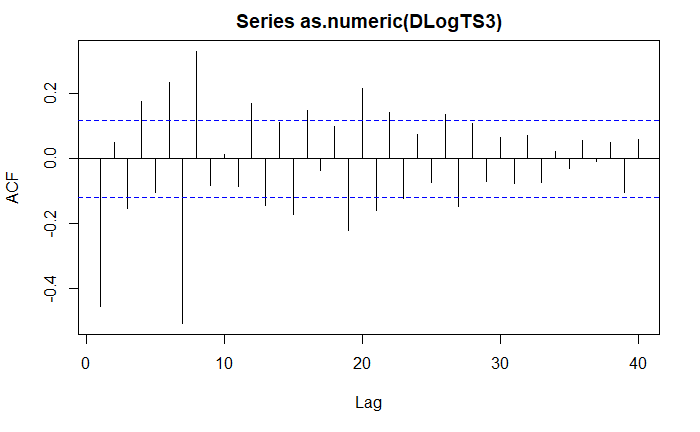

```r
acf(as.numeric(DLogTS3), lag.max=40)
```

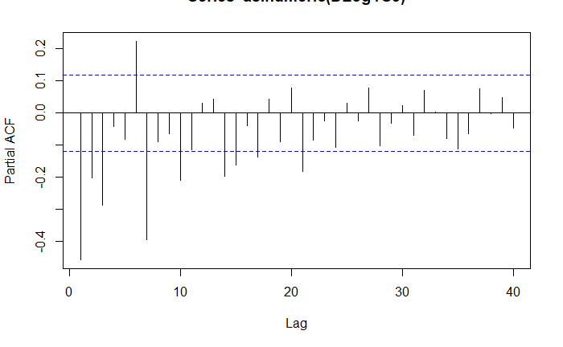

```r
pacf(as.numeric(DLogTS3), lag.max=40)
```

Conclusion : Il est judicieux de considérer les séries DLogTS2 et DLogTS dont la stationnarité est soutenue par l’analyse visuelle et les tests ADF et KPSS. On notera aussi qu’on a éliminé les tendances et les saisonnalités sur ces séries.

```r
mod3 = auto.arima(LogTS,allowmean = TRUE, max.D = 1, max.d = 0, allowdrift = TRUE)
mod3
```

```
Series: LogTS
ARIMA(2,0,3)(0,1,1)[7]

Coefficients:
         ar1     ar2     ma1      ma2      ma3     sma1
      0.0029  0.9425  0.3743  -0.7034  -0.1822  -0.6871
s.e.  0.0392  0.0375  0.0708   0.0684   0.0602   0.0497

sigma^2 estimated as 0.01505:  log likelihood=186.18
AIC=-358.37   AICc=-357.94   BIC=-333.1
```

Le terme ar1 n’est pas significatif, mais le terme ar2 l’étant, on ne va pas modifier notre modèle

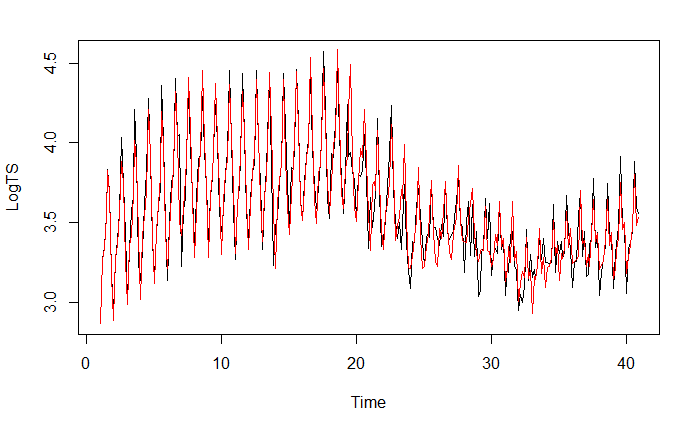

```r
plot(LogTS)
lines(mod3$fitted,col='red')
```

Analyse des résidus du modèle

```
    Box-Ljung test

data:  res
X-squared = 1.0919, df = 7, p-value = 0.9932


    KPSS Test for Level Stationarity

data:  res
KPSS Level = 0.1696, Truncation lag parameter = 5, p-value = 0.1


    Augmented Dickey-Fuller Test

data:  res[which(!is.na(res))]
Dickey-Fuller = -6.0884, Lag order = 6, p-value = 0.01
alternative hypothesis: stationary


    Shapiro-Wilk normality test

data:  res
W = 0.96552, p-value = 3.054e-06
```

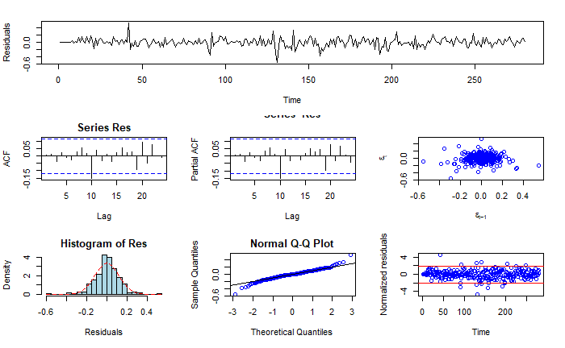

```r
check_stat(mod3$residuals)
```

Deuxième modèle

```r
mod4 = auto.arima(LogTS,allowmean = TRUE, max.D = 1, max.d = 1, allowdrift = TRUE)
mod4
```

```
Series: LogTS
ARIMA(2,0,3)(0,1,1)[7]

Coefficients:
         ar1     ar2     ma1      ma2      ma3     sma1
      0.0029  0.9425  0.3743  -0.7034  -0.1822  -0.6871
s.e.  0.0392  0.0375  0.0708   0.0684   0.0602   0.0497

sigma^2 estimated as 0.01505:  log likelihood=186.18
AIC=-358.37   AICc=-357.94   BIC=-333.1
```

C’est le même modèle !